# Exam3_example

## This is just a template for how to turn an Rmarkdown file into a web page that you can link from your main website…

For this example, we will be using the *tidyverse* package and the built-in *iris* dataset.

First thing is to load the packages and the data that we need:

```r
library(tidyverse)
library(GGally)
library(modelr)
data("iris")
```

Next, we’ll take a quick look at the data:

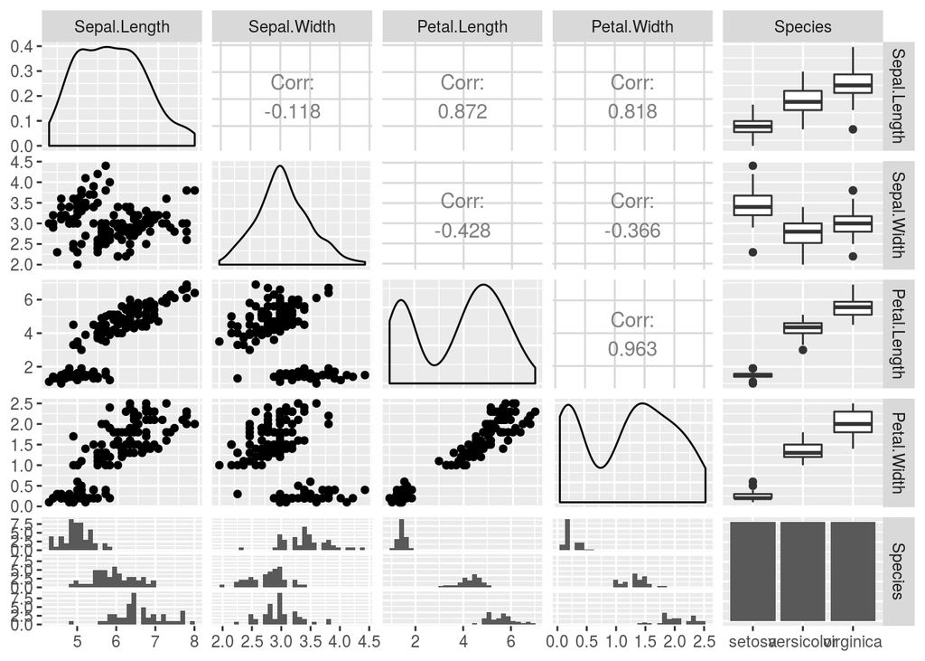

```r
ggpairs(iris)
```

For this example, we will be using the column “Sepal.Length” as our dependent variable, so we will build a quick plot showing its relationship to Sepal.Width and species:

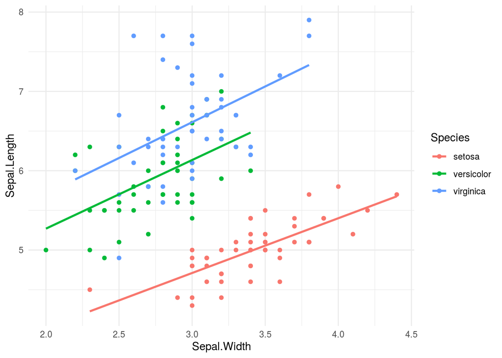

```r
ggplot(iris, aes(x=Sepal.Width,y=Sepal.Length,color=Species)) +
  geom_point() +
  geom_smooth(method="lm",se=FALSE) +
  theme_minimal()
```

Looks to me like there’s a positive relationship between Sepal.Width and Sepal.Length, and that this varies based on Species. Let’s build a simple model:

```r
mod <- glm(data=iris,formula = Sepal.Length ~ Sepal.Width * Species)
```

We can use the modelr package to make predictions from our model. I’ll go ahead and pipe that new data frame straight into ggplot to compare reality with my model predictions:

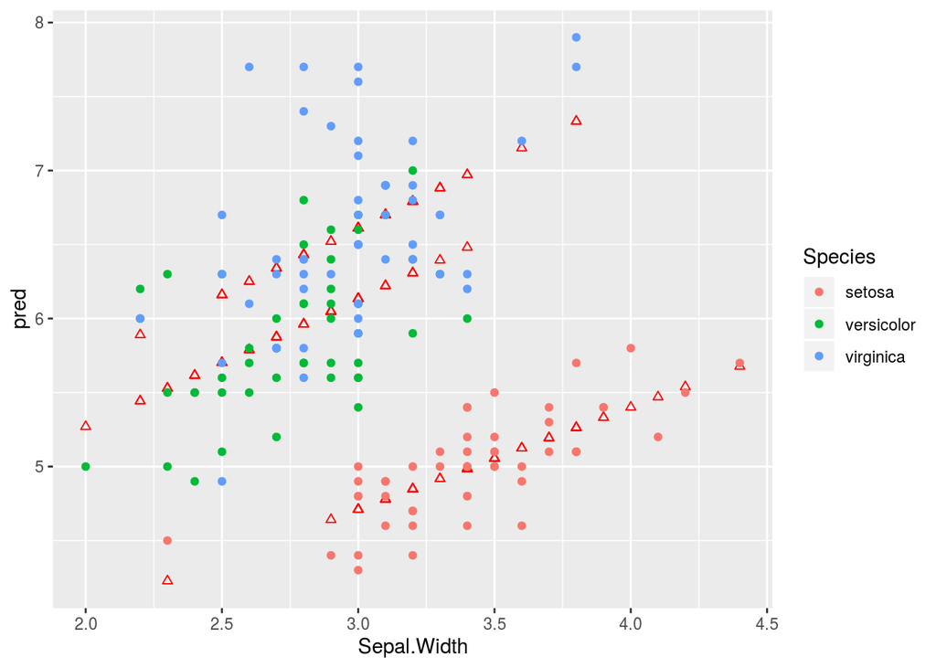

```r
add_predictions(iris,mod) %>%
  ggplot(aes(x=Sepal.Width)) +
  geom_point(aes(y=pred),color="Red",shape=2) +
  geom_point(aes(y=Sepal.Length,color=Species))
```

For the sake of simplicity, I’ll finish my web page here. Your own analyses should use cross-validation when needed, do more exploatory work, and possibly compare a few different models to see which is a better predictor of reality…